# Making Effective Display of Data

Feb 13, 2019

## Anscombe's data

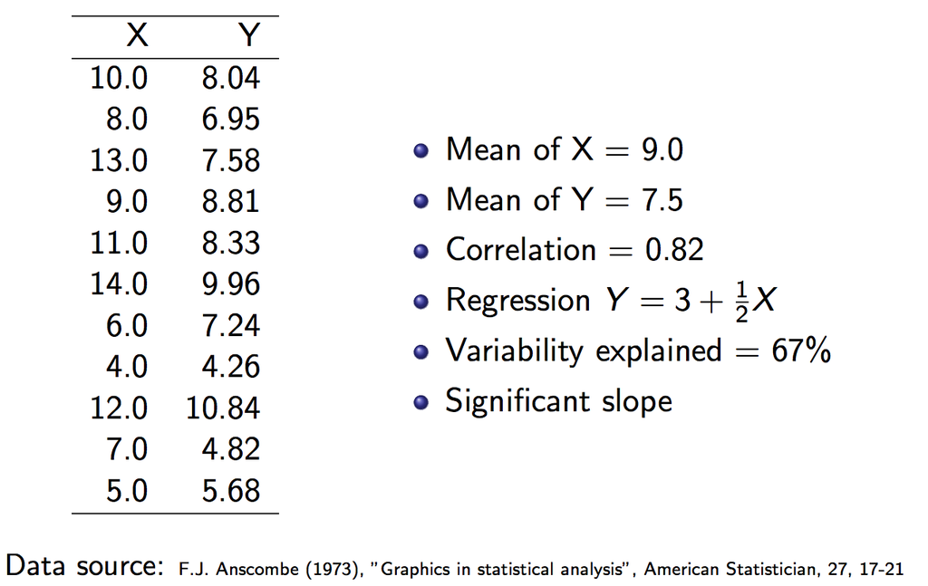

## Anscombe's data

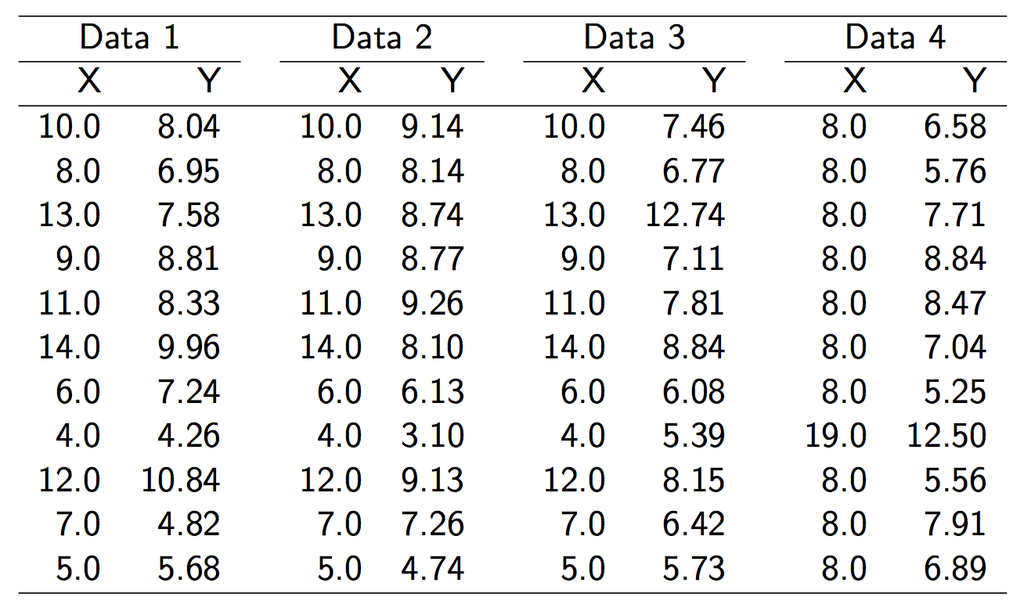

## Anscombe's data

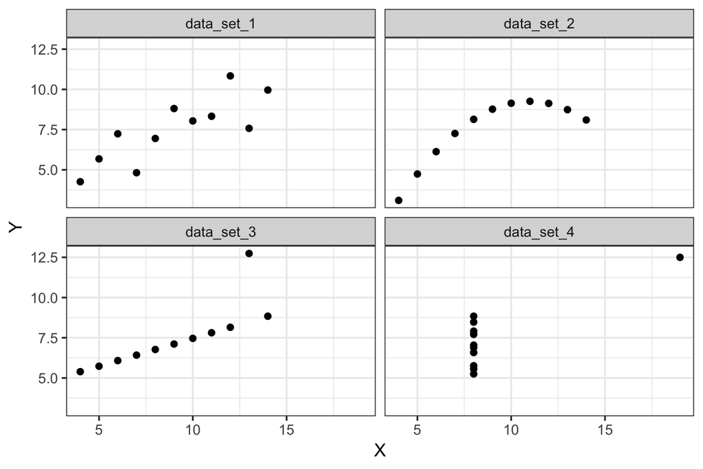

## Space time story

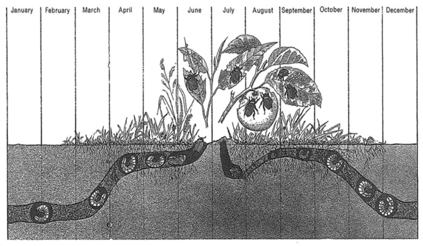

## Abusing the power of graphics

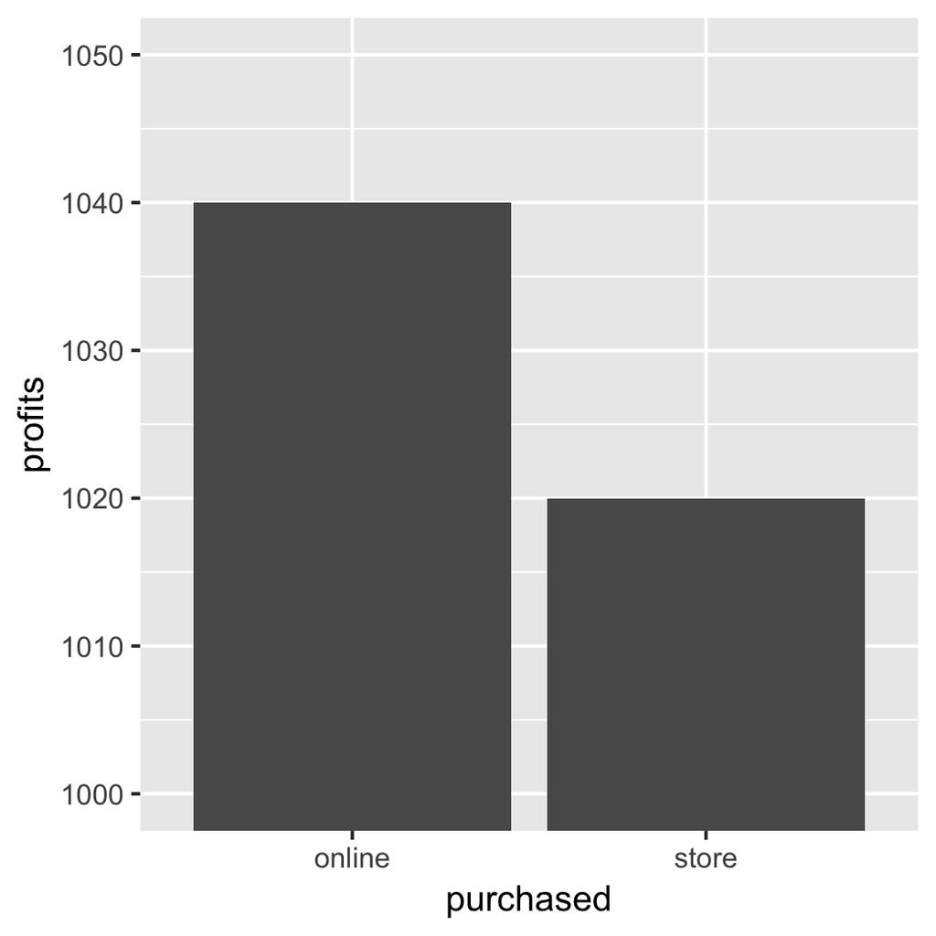

## Abusing the power of graphics

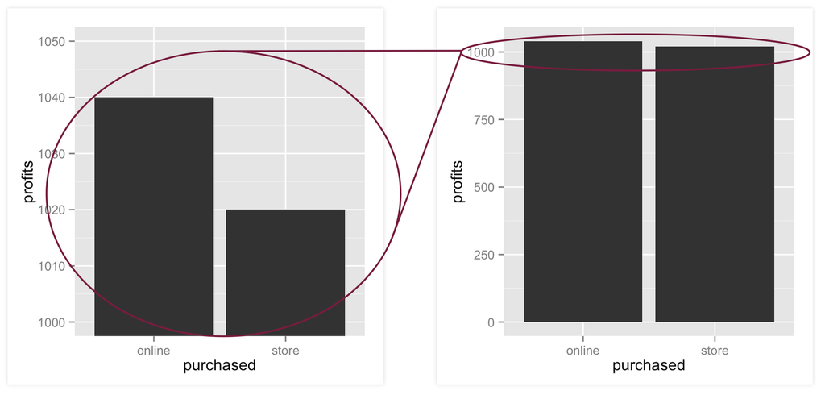

## Effective display of data

- Generate graphics effectively
  - consistency of plots
  - avoid common mistakes
- Create informative plots
  - starts with a simple display
  - extension of a graphics without changing much
  - complex graphics to be generated in less effort
  - displays data in several level of details
- Grammar of graphics help us achieve the goal

## Grammar of graphics

- Leland Wilkinson (1999)
  - grammar of graphics
- Hadley Wickham (2005)
  - continued working with the grammar
  - implemented in `R`:
  - layered grammar of graphics (2010)
- `R` packages we will use in this lecture

```r
  install.packages(c("ggplot2", "ggmap", "gapminder", "reshape2"))
```

## How the grammar works

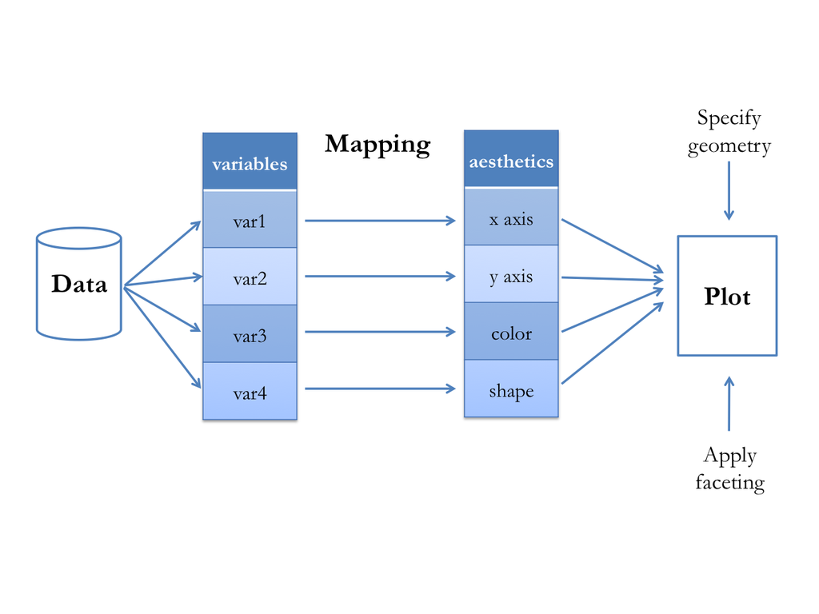

## Example: data mapping to aesthetics

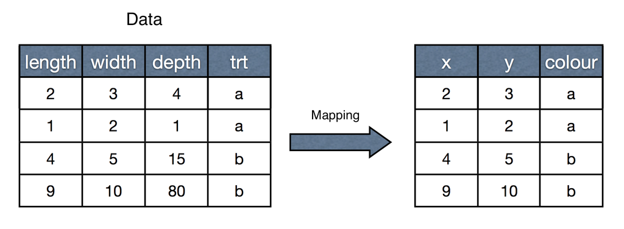

- Plot aesthetics
  - X is mapped to length
  - Y is mapped to width
  - color is mapped to trt

## Example: Car milage data

```r
head(mtcars)
```

```
##                    mpg cyl disp  hp drat    wt  qsec vs am gear carb
## Mazda RX4         21.0   6  160 110 3.90 2.620 16.46  0  1    4    4
## Mazda RX4 Wag     21.0   6  160 110 3.90 2.875 17.02  0  1    4    4
## Datsun 710        22.8   4  108  93 3.85 2.320 18.61  1  1    4    1
## Hornet 4 Drive    21.4   6  258 110 3.08 3.215 19.44  1  0    3    1
## Hornet Sportabout 18.7   8  360 175 3.15 3.440 17.02  0  0    3    2
## Valiant           18.1   6  225 105 2.76 3.460 20.22  1  0    3    1
```

- We want to map
  - disp to X
  - mpg to Y
  - cyl to color
- We choose geom to be point

## Example: ggplot

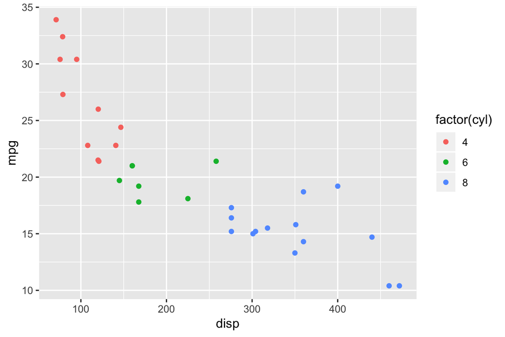

```r
ggplot(data = mtcars, aes(x = disp, y = mpg, color = factor(cyl))) +
  geom_point()
```

## Example: ggplot

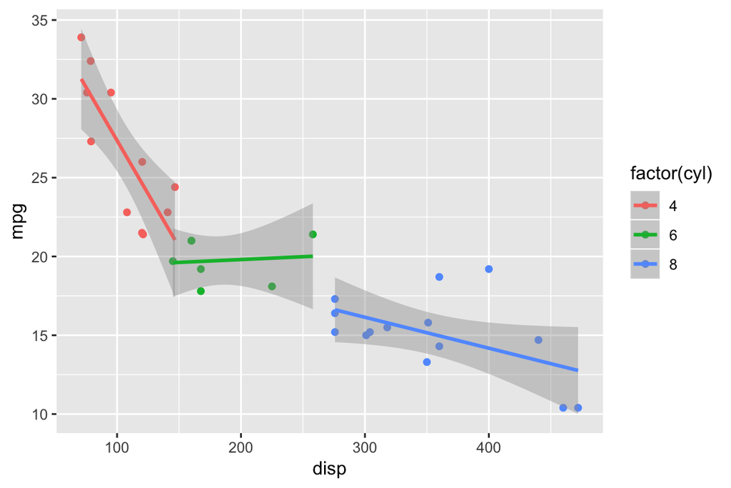

```r
ggplot(data = mtcars, aes(x = disp, y = mpg, color = factor(cyl))) +
  geom_point() + geom_smooth(method="lm")
```

## Example: ggplot

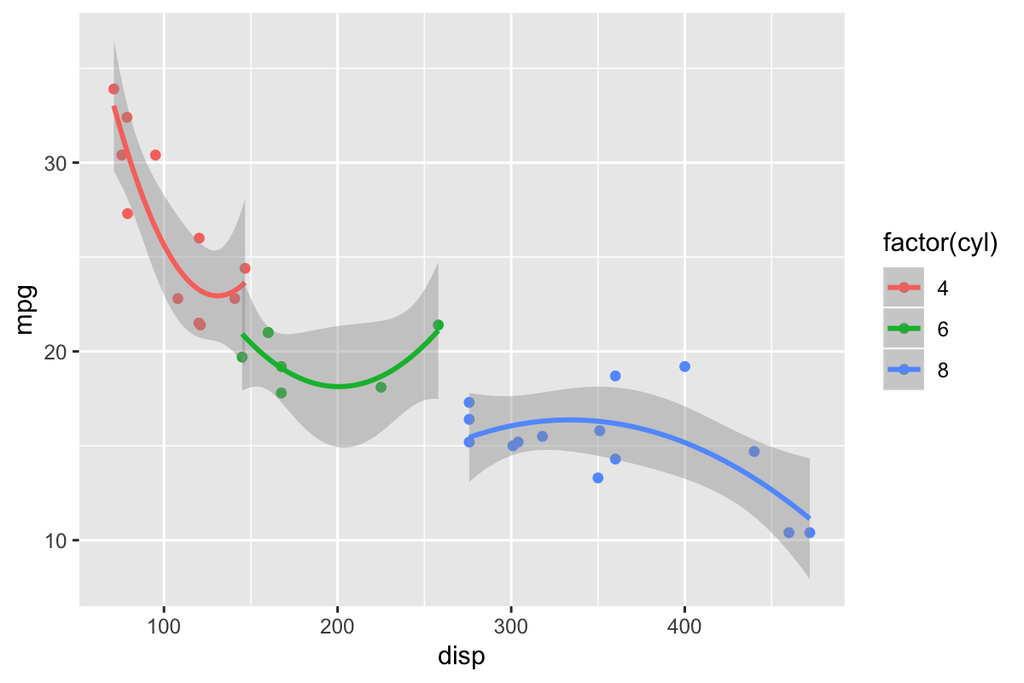

```r
ggplot(data = mtcars, aes(x = disp, y = mpg, color = factor(cyl))) +
  geom_point() + geom_smooth(method="lm", formula=y ~ poly(x, 2, raw=TRUE))
```

## Case study: exploratory visualization

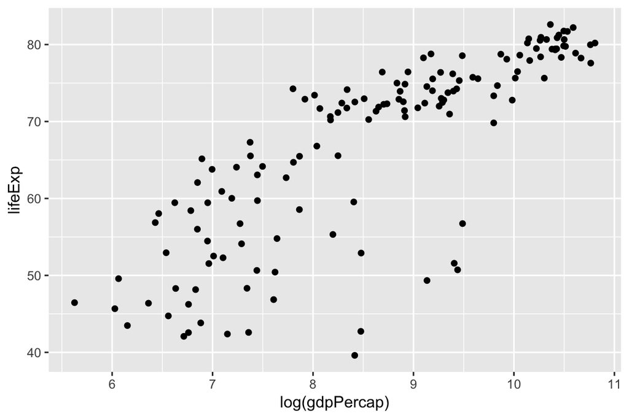

```r
library(gapminder)
dat <- subset(gapminder, year == 2007)
q <- ggplot(data = dat, aes(x = log(gdpPercap), y = lifeExp))
q + geom_point()
```

## Case study: exploratory visualization

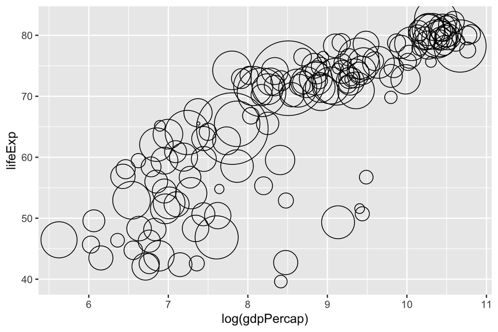

```r
q + geom_point(aes(size = sqrt(pop/pi)), pch = 21, show.legend = FALSE) +
   scale_size_continuous(range=c(1,30))
```

## Case study: exploratory visualization

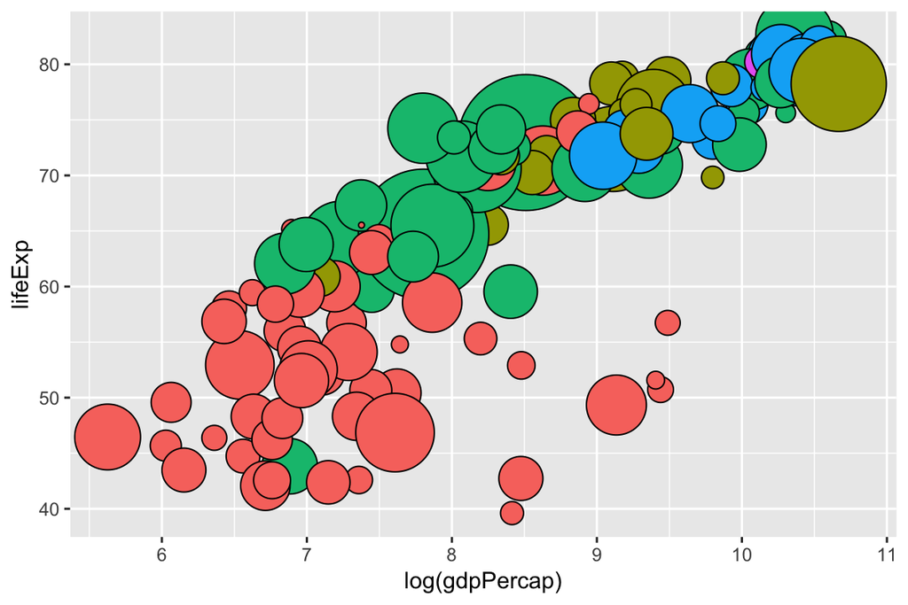

```r
q + geom_point(aes(size = sqrt(pop/pi)), pch = 21, show.legend = FALSE) +
   scale_size_continuous(range=c(1,30)) + aes(fill = continent)
```

## Case study: exploratory visualization

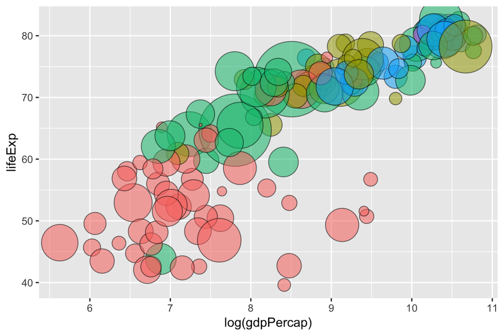

```r
q + geom_point(aes(size = sqrt(pop/pi)), pch = 21, show.legend = FALSE) +
   scale_size_continuous(range=c(1,30)) + aes(fill = continent, alpha=0.3)
```

## Faceting in display

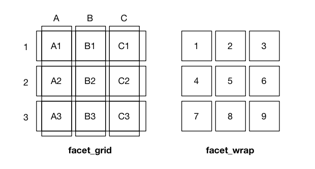

- Display same plot condition on other categorical variable
- Two types of facetting
  - facet_grid(var1~var2)
  - facet_wrap(~var1)

## Example: Faceting

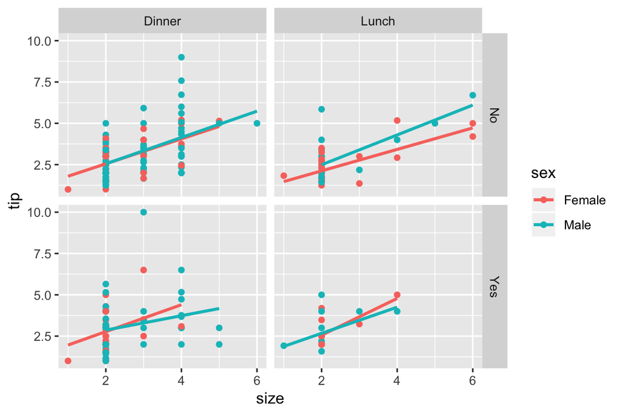

```r
library(reshape2)
ggplot(tips, aes(size, tip, color=sex)) + geom_point() +
  geom_smooth(method="lm", se=FALSE) + facet_grid(smoker~time)
```

## References

- [The Grammar of Graphics](http://books.google.com/books/about/The_Grammar_of_Graphics.html?id=_kRX4LoFfGQC), by Leland Wilkinson.
- [A Layered Grammar of Graphics](http://byrneslab.net/classes/biol607/readings/wickham_layered-grammar.pdf) by Hadley Wickham.
- [ggplot2](http://www.springer.com/statistics/computational+statistics/book/978-0-387-98140-6), Elegant Graphics for Data Analysis by Hadley Wickham.
- [ggplot2, an Implimentation of Grammar of Graphics](http://ggplot2.org/resources/2007-vanderbilt.pdf) a talk given by Hadley Wickham at Vanderbilt University.
- `ggplot2` web site with nice documentation  
  http://docs.ggplot2.org/current/